# Codebook for drugs

Autogenerated data summary from dataReporter

2023-04-17 00:58:35

# Data report overview

The dataset examined has the following dimensions:

| Feature | Result |
| --- | --- |
| Number of observations | 1701 |
| Number of variables | 13 |

# Codebook summary table

| Label | Variable | Class | # unique values | Missing | Description |
| --- | --- | --- | --- | --- | --- |
|  | **category** | character | 1 | 0.00 % |  |
|  | **therapeutic_area** | character | 669 | 0.12 % |  |
|  | **authorisation_status** | character | 3 | 0.00 % |  |
|  | **generic** | logical | 2 | 0.00 % |  |
|  | **biosimilar** | logical | 2 | 0.00 % |  |
|  | **accelerated_assessment** | logical | 2 | 0.00 % |  |
|  | **orphan_medicine** | logical | 2 | 0.00 % |  |
|  | **marketing_authorisation_date** | Date | 967 | 3.00 % |  |
|  | **date_of_refusal_of_marketing_authorisation** | Date | 64 | 95.83 % |  |
|  | **marketing_authorisation_holder_company_name** | character | 544 | 0.18 % |  |
|  | **holder_name** | character | 379 | 0.18 % |  |
|  | **brandname** | logical | 2 | 0.00 % |  |
|  | **year** | numeric | 29 | 0.00 % |  |

# Variable list

## category

- The variable only takes one (non-missing) value: "human". The variable contains 0 % missing observations.

## therapeutic_area

| Feature | Result |
| --- | --- |
| Variable type | character |
| Number of missing obs. | 2 (0.12 %) |
| Number of unique values | 668 |
| Mode | “Diabetes Mellitus, Type 2” |

[figure not shown]

- Observed factor levels: "Abdominal Neoplasms", "Achondroplasia", "Acid sphingomyelinase deficiency (ASMD) type A/B or type B", "Acidosis, Renal Tubular", "Acromegaly", "Acromegaly; Pituitary ACTH Hypersecretion", "Acute Coronary Syndrome", "Acute Coronary Syndrome; Angina, Unstable; Myocardial Infarction", "Acute Coronary Syndrome; Coronary Artery Disease; Peripheral Arterial Disease; Venous Thromboembolism; Stroke; Atrial Fibrillation; Pulmonary Embolism", "Acute Coronary Syndrome; Myocardial Infarction", "Acute Coronary Syndrome; Peripheral Vascular Diseases; Myocardial Infarction; Stroke", "Acute Coronary Syndrome; Vascular Surgical Procedures", "Acute Pain", "Adenomatous Polyposis Coli", "Adrenal Cortex Neoplasms", "Adrenal Hyperplasia, Congenital", "Adrenal Insufficiency", "Adrenoleukodystrophy", "Alagille Syndrome", "Alcohol-Related Disorders", "alpha-Mannosidosis", "Alzheimer Disease", "Alzheimer Disease; Dementia; Parkinson Disease", "Alzheimer Disease; Parkinson Disease; Dementia", "Amino Acid Metabolism, Inborn Errors", "Amino Acid Metabolism, Inborn Errors; Propionic Acidemia", "Amyloid Neuropathies, Familial", "Amyloidosis", "Amyloidosis, Familial", "Amyotrophic Lateral Sclerosis", "Anemia, Iron-Deficiency", "Anemia, Sickle Cell", "Anemia; Anemia, Hemolytic; Anemia, Sickle Cell", "Anemia; Blood Transfusion, Autologous; Cancer; Kidney Failure, Chronic", "Anemia; Blood Transfusion, Autologous; Kidney Failure, Chronic; Cancer", "Anemia; Cancer; Kidney Failure, Chronic", "Anemia; Kidney Failure, Chronic", "Anemia; Kidney Failure, Chronic; Cancer", "Anemia; Myelodysplastic Syndromes; beta-Thalassemia", "Angina Pectoris", "Angina Pectoris; Heart Failure", "Angina, Unstable; Myocardial Infarction", "Angioedema", "Angioedemas, Hereditary", "Anovulation", "Anovulation; Reproductive Techniques, Assisted; Infertility, Female", "Anovulation; Reproductive Techniques, Assisted; Infertility, Female; Hypogonadism", "Anthrax", "Antithrombin III Deficiency", "Anxiety Disorders; Depressive Disorder, Major; Diabetic Neuropathies", "Anxiety Disorders; Diabetic Neuropathies; Depressive Disorder, Major", "Anxiety Disorders; Epilepsy", "Anxiety Disorders; Neuralgia; Epilepsy", "Apnea", "Arthritis, Psoriatic; Arthritis, Juvenile Rheumatoid; Arthritis, Rheumatoid", "Arthritis, Psoriatic; Arthritis, Juvenile Rheumatoid; Arthritis, Rheumatoid; Colitis, Ulcerative; Crohn Disease; Hidradenitis Suppurativa; Psoriasis; Spondylitis, Ankylosing; Uveitis", "Arthritis, Psoriatic; Arthritis, Rheumatoid; Psoriasis", "Arthritis, Psoriatic; Colitis, Ulcerative; Arthritis, Juvenile Rheumatoid; Spondylitis, Ankylosing; Psoriasis; Crohn Disease; Arthritis, Rheumatoid", "Arthritis, Psoriatic; Precursor Cell Lymphoblastic Leukemia-Lymphoma; Psoriasis; Arthritis, Rheumatoid; Arthritis", "Arthritis, Psoriatic; Psoriasis", "Arthritis, Psoriatic; Psoriasis; Arthritis, Juvenile Rheumatoid; Arthritis, Rheumatoid", "Arthritis, Psoriatic; Psoriasis; Arthritis, Juvenile Rheumatoid; Arthritis, Rheumatoid; Spondylitis, Ankylosing", "Arthritis, Psoriatic; Psoriasis; Crohn Disease; Arthritis, Rheumatoid; Colitis, Ulcerative; Spondylitis, Ankylosing", "Arthritis, Psoriatic; Psoriasis; Spondylitis, Ankylosing", "Arthritis, Psoriatic; Spondylitis, Ankylosing; Colitis, Ulcerative; Arthritis, Rheumatoid", "Arthritis, Psoriatic; Spondylitis, Ankylosing; Colitis, Ulcerative; Arthritis, Rheumatoid; Crohn Disease; Psoriasis", "Arthritis, Psoriatic; Spondylitis, Ankylosing; Colitis, Ulcerative; Psoriasis; Crohn Disease; Arthritis, Rheumatoid", "Arthritis, Psoriatic; Spondylitis, Ankylosing; Crohn Disease; Colitis, Ulcerative; Hidradenitis Suppurativa; Psoriasis; Arthritis, Rheumatoid", "Arthritis, Psoriatic; Spondylitis, Ankylosing; Psoriasis", "Arthritis, Rheumatoid", "Arthritis, Rheumatoid; Arthritis, Juvenile Rheumatoid; Arthritis, Psoriatic; Spondylarthropathies; Spondylitis, Ankylosing; Psoriasis", "Arthritis, Rheumatoid; Arthritis, Juvenile Rheumatoid; Cytokine Release Syndrome; Giant Cell Arteritis; COVID-19 virus infection", "Arthritis, Rheumatoid; Arthritis, Juvenile Rheumatoid; Psoriasis; Arthritis, Psoriatic; Spondylitis, Ankylosing; Uveitis; Colitis, Ulcerative; Crohn Disease", "Arthritis, Rheumatoid; Arthritis, Juvenile Rheumatoid; Spondylitis, Ankylosing; Arthritis, Psoriatic; Psoriasis; Hidradenitis Suppurativa; Crohn Disease; Colitis, Ulcerative; Uveitis", "Arthritis, Rheumatoid; Arthritis, Psoriatic", "Arthritis, Rheumatoid; Arthritis, Psoriatic; Psoriasis; Spondylitis, Ankylosing; Uveitis; Hidradenitis Suppurativa; Colitis, Ulcerative; Crohn Disease; Arthritis, Juvenile Rheumatoid", "Arthritis, Rheumatoid; Arthritis, Psoriatic; Spondylitis, Ankylosing; Uveitis; Hidradenitis Suppurativa; Colitis, Ulcerative; Arthritis, Juvenile Rheumatoid; Crohn Disease; Skin Diseases, Papulosquamous", "Arthritis, Rheumatoid; COVID-19 virus infection", "Arthritis, Rheumatoid; Osteoarthritis; Dysmenorrhea", "Arthroplasty, Replacement; Venous Thromboembolism", "Arthroplasty; Venous Thromboembolism", "Ascites; Cancer", "Aspergillosis", "Aspergillosis; Candidiasis; Mycoses", "Asthma", "Asthma; Pulmonary Disease, Chronic Obstructive", "Asthma; Urticaria", "Atrial Fibrillation", "Atrial Fibrillation; Atrial Flutter", "Attention Deficit Disorder with Hyperactivity", "Bacterial Infections", "Bacterial Infections and Mycoses; Aspergillosis; Candidiasis", "Bacterial Infections; Skin Diseases, Bacterial; Soft Tissue Infections", "Barrett Esophagus", "beta-Thalassemia", "beta-Thalassemia; Iron Overload", "Bipolar Disorder", "Blood Coagulation Disorders, Inherited", "Bone Resorption; Osteoporosis, Postmenopausal", "Breast Neoplasms", "Breast Neoplasms; Liposarcoma", "Breast Neoplasms; Neoplasm Metastasis", "Breast Neoplasms; Neoplasm Metastasis; Fractures, Bone", "Breast Neoplasms; Neoplasm Metastasis; Fractures, Bone; Osteoporosis, Postmenopausal", "Breast Neoplasms; Ovarian Neoplasms", "Breast Neoplasms; Ovarian Neoplasms; Multiple Myeloma; Sarcoma, Kaposi", "Breast Neoplasms; Pancreatic Neoplasms; Carcinoma, Non-Small-Cell Lung", "Breast Neoplasms; Stomach Neoplasms", "Breast Neoplasms; Triple Negative Breast Neoplasms", "Breath Tests; Helicobacter Infections", "Cachexia; Anorexia; Carcinoma, Non-Small-Cell Lung", "Cancer; Carcinoma, Non-Small-Cell Lung", "Cancer; Fractures, Bone", "Candidiasis", "Candidiasis; Aspergillosis", "Candidiasis; Mycoses; Aspergillosis", "Candidiasis; Mycoses; Coccidioidomycosis; Aspergillosis", "Carbamoyl-Phosphate Synthase I Deficiency Disease", "Carcinoid Tumor; Leukemia, Hairy Cell; Lymphoma, Follicular; Hepatitis B, Chronic; Hepatitis C, Chronic; Leukemia, Myelogenous, Chronic, BCR-ABL Positive; Melanoma; Multiple Myeloma", "Carcinoid Tumor; Neuroendocrine Tumors", "Carcinoma, Basal Cell", "Carcinoma, Hepatocellular", "Carcinoma, Hepatocellular; Carcinoma, Renal Cell", "Carcinoma, Non-Small-Cell Lung", "Carcinoma, Non-Small-Cell Lung; Breast Neoplasms; Ovarian Neoplasms; Colorectal Neoplasms; Carcinoma, Renal Cell", "Carcinoma, Non-Small-Cell Lung; Breast Neoplasms; Prostatic Neoplasms", "Carcinoma, Non-Small-Cell Lung; Mesothelioma", "Carcinoma, Non-Small-Cell Lung; Pancreatic Neoplasms", "Carcinoma, Non-Small-Cell Lung; Thyroid Neoplasms", "Carcinoma, Renal Cell", "Carcinoma, Renal Cell; Breast Neoplasms; Pancreatic Neoplasms", "Carcinoma, Renal Cell; Carcinomas, Hepatocellular", "Carcinoma, Renal Cell; Lymphoma, Mantle-Cell", "Carcinoma, Renal Cell; Peritoneal Neoplasms; Ovarian Neoplasms; Breast Neoplasms; Carcinoma, Non-Small-Cell Lung; Fallopian Tube Neoplasms", "Carcinoma, Squamous Cell", "Carcinoma, Transitional Cell; Carcinoma, Non-Small-Cell Lung; Urologic Neoplasms; Breast Neoplasms; Small Cell Lung Carcinoma", "Carcinoma, Transitional Cell; Urologic Neoplasms", "Carcinoma; Small Cell Lung Carcinoma", "Cartilage Diseases", "Cataplexy; Narcolepsy", "Chickenpox; Rubella; Measles; Mumps; Immunization", "Cholangiocarcinoma", "Cholera", "Cholera; Immunization", "Cholestasis, Intrahepatic", "Cholestasis; Vitamin E Deficiency", "Clostridium Infections", "Colitis, Ulcerative; Crohn Disease", "Colonic Neoplasms; Breast Neoplasms; Colorectal Neoplasms; Stomach Neoplasms", "Colorectal Neoplasms", "Colorectal Neoplasms; Breast Neoplasms; Carcinoma, Non-Small-Cell Lung; Carcinoma, Renal Cell; Uterine Cervical Neoplasms", "Colorectal Neoplasms; Breast Neoplasms; Ovarian Neoplasms; Carcinoma, Non-Small-Cell Lung; Carcinoma, Renal Cell", "Colorectal Neoplasms; Breast Neoplasms; Ovarian Neoplasms; Fallopian Tube Neoplasms; Peritoneal Neoplasms; Carcinoma, Non-Small-Cell Lung; Carcinoma, Renal Cell; Uterine Cervical Neoplasms", "Colorectal Neoplasms; Breast Neoplasms; Ovarian Neoplasms; Peritoneal Neoplasms; Carcinoma, Non-Small-Cell Lung; Carcinoma, Renal Cell; Uterine Cervical Neoplasms", "Colorectal Neoplasms; Colonoscopy", "Community-Acquired Infections", "Community-Acquired Infections; Pharyngitis; Bronchitis, Chronic; Pneumonia; Tonsillitis; Sinusitis", "Community-Acquired Infections; Skin Diseases, Infectious; Pneumonia", "Community-Acquired Infections; Streptococcal Infections; Staphylococcal Infections; Gram-Negative Bacterial Infections; Surgical Wound Infection; Pneumonia, Bacterial", "Condylomata Acuminata", "Condylomata Acuminata; Keratosis; Keratosis, Actinic; Carcinoma, Basal Cell", "Condylomata Acuminata; Papillomavirus Infections; Immunization; Uterine Cervical Dysplasia", "Conjunctivitis, Allergic", "Conjunctivitis; Keratitis", "Conscious Sedation", "Constipation", "Constipation; Opioid-Related Disorders", "Contraception", "Contraception, Postcoital", "Contraceptives, Oral", "Corneal Diseases", "Corneal Diseases; Cystinosis", "COVID-19 virus infection", "Crohn Disease", "Cryopyrin-Associated Periodic Syndromes", "Cryopyrin-Associated Periodic Syndromes; Arthritis, Juvenile Rheumatoid; Arthritis, Gouty", "Cushing Syndrome", "Cystic Fibrosis", "Cystic Fibrosis; Respiratory Tract Infections", "Cystinosis", "Cystitis, Interstitial", "Cytomegalovirus Infections", "Cytomegalovirus Retinitis", "Cytomegalovirus Retinitis; HIV Infections", "Debridement", "Dementia; Alzheimer Disease; Parkinson Disease", "Dengue", "Depressive Disorder", "Depressive Disorder, Major", "Dermatitis, Atopic", "Dermatitis, Atopic; Prurigo; Esophageal Diseases; Asthma; Sinusitis", "Dermatofibrosarcoma; Gastrointestinal Stromal Tumors; Leukemia, Myelogenous, Chronic, BCR-ABL Positive", "Desensitization, Immunologic; Kidney Transplantation", "Diabetes Mellitus", "Diabetes Mellitus, Type 1", "Diabetes Mellitus, Type 2", "Diabetes Mellitus, Type 2; Diabetes Mellitus; Nutritional and Metabolic Diseases; Metabolic Diseases; Glucose Metabolism Disorders", "Diabetes Mellitus, Type 2; Heart Failure, Systolic; Heart Failure; Renal Insufficiency, Chronic", "Diabetic Neuropathies", "Diagnostic Techniques, Endocrine", "Digestive System Diseases; Metabolism, Inborn Errors", "Disease Outbreaks; Influenza, Human; Immunization", "Drug-Related Side Effects and Adverse Reactions", "Ductus Arteriosus, Patent", "Dupuytren Contracture", "Dyslipidemias", "Dyslipidemias; Hypercholesterolemia", "Echocardiography", "Encephalitis, Japanese; Immunization", "Endometrial Neoplasms", "Enterocolitis, Pseudomembranous", "Epidermolysis Bullosa Dystrophica; Epidermolysis Bullosa, Junctional", "Epilepsies, Myoclonic", "Epilepsies, Partial", "Epilepsy", "Epilepsy; Anxiety Disorders; Neuralgia", "Erectile Dysfunction", "Esophageal Diseases", "Essential Hypertension", "Exocrine Pancreatic Insufficiency", "Extravasation of Diagnostic and Therapeutic Materials", "Fabry Disease", "Factor X Deficiency", "Fallopian Tube Neoplasms; Peritoneal Neoplasms; Ovarian Neoplasms", "Fibromyalgia", "Fractures, Bone", "Fractures, Bone; Cancer", "Fractures, Bone; Neoplasm Metastasis", "Fractures, Cartilage", "Friedreich Ataxia", "Gastroesophageal Reflux", "Gastrointestinal Stromal Tumors", "Gastrointestinal Stromal Tumors; Carcinoma, Renal Cell; Neuroendocrine Tumors", "Gaucher Disease", "Gaucher Disease; Niemann-Pick Diseases", "Genetic Diseases, Inborn; Anemia, Hemolytic", "Genetic Diseases, Inborn; Lung Diseases", "Giant Cell Tumor of Tendon Sheath; Synovitis, Pigmented Villonodular", "Giant Lymph Node Hyperplasia", "Glaucoma, Open-Angle; Ocular Hypertension", "Glioma", "Glioma; Glioblastoma", "Glomerulonephritis, IGA", "Glycogen Storage Disease Type II", "Gout", "Graft Rejection", "Graft Rejection; Kidney Transplantation", "Gram-Negative Bacterial Infections", "Gram-Positive Bacterial Infections; Bacteremia; Soft Tissue Infections; Endocarditis, Bacterial", "Growth", "Growth and Development", "Guided Tissue Regeneration, Periodontal", "Head and Neck Neoplasms; Carcinoma, Non-Small-Cell Lung; Adenocarcinoma; Prostatic Neoplasms; Breast Neoplasms", "Head and Neck Neoplasms; Carcinoma, Non-Small-Cell Lung; Adenocarcinoma; Prostatic Neoplasms; Stomach Neoplasms; Breast Neoplasms", "Head and Neck Neoplasms; Carcinoma, Squamous Cell", "Head and Neck Neoplasms; Colorectal Neoplasms", "Heart Failure", "Hemangioma", "Hematopoietic Stem Cell Transplantation", "Hematopoietic Stem Cell Transplantation; Graft vs Host Disease", "Hematopoietic Stem Cell Transplantation; Neoplasms", "Hemoglobinuria, Paroxysmal", "Hemolysis; Anemia, Hemolytic, Autoimmune", "Hemophilia A", "Hemophilia A; Hemophilia B", "Hemophilia A; von Willebrand Diseases", "Hemophilia B", "Hemophilia B; Thrombasthenia; Factor VII Deficiency; Hemophilia A", "Hemorrhage", "Hemorrhagic Fever, Ebola", "Hemostasis", "Hemostasis, Surgical", "Hepatic Veno-Occlusive Disease", "Hepatitis B", "Hepatitis B, Chronic", "Hepatitis B, Chronic; HIV Infections", "Hepatitis B; Hepatitis A; Immunization", "Hepatitis B; Immunization", "Hepatitis B; Meningitis, Haemophilus; Immunization", "Hepatitis B; Tetanus; Immunization; Diphtheria", "Hepatitis B; Tetanus; Immunization; Meningitis, Haemophilus; Whooping Cough; Diphtheria", "Hepatitis B; Tetanus; Immunization; Meningitis, Haemophilus; Whooping Cough; Poliomyelitis; Diphtheria", "Hepatitis B; Tetanus; Immunization; Whooping Cough; Diphtheria", "Hepatitis B; Tetanus; Immunization; Whooping Cough; Poliomyelitis; Diphtheria", "Hepatitis C, Chronic", "Hepatitis C, Chronic; Hepatitis B, Chronic", "Hepatitis D, Chronic", "Hepatolenticular Degeneration", "Herpes Zoster", "Herpes Zoster; Immunization", "Hidradenitis Suppurativa; Arthritis, Psoriatic; Psoriasis; Crohn Disease; Arthritis, Juvenile Rheumatoid; Uveitis; Arthritis, Rheumatoid; Colitis, Ulcerative; Spondylitis, Ankylosing", "Hidradenitis Suppurativa; Psoriasis; Arthritis, Juvenile Rheumatoid; Uveitis; Arthritis, Rheumatoid; Spondylitis, Ankylosing; Arthritis, Psoriatic", "Hidradenitis Suppurativa; Psoriasis; Uveitis; Arthritis, Rheumatoid; Spondylitis, Ankylosing; Crohn Disease; Colitis, Ulcerative; Arthritis, Psoriatic", "Hirsutism", "HIV Infections", "Hodgkin Disease; Lymphoma, Non-Hodgkin", "Homocystinuria", "Hyperammonemia; Amino Acid Metabolism, Inborn Errors", "Hypercalcemia", "Hypercalcemia; Breast Neoplasms; Neoplasm Metastasis; Fractures, Bone", "Hypercalcemia; Cancer", "Hypercalcemia; Fractures, Bone; Cancer", "Hypercalcemia; Fractures, Bone; Neoplasm Metastasis; Breast Neoplasms", "Hypercalcemia; Osteitis Deformans; Bone Resorption", "Hypercalcemia; Parathyroid Neoplasms; Hyperparathyroidism", "Hypercholesterolemia", "Hypercholesterolemia; Dyslipidemias", "Hyperkalemia", "Hyperlipoproteinemia Type I", "Hyperoxaluria, Primary", "Hyperparathyroidism", "Hyperparathyroidism, Secondary", "Hyperparathyroidism, Secondary; Hypercalcemia", "Hyperphosphatemia", "Hyperphosphatemia; Renal Dialysis", "Hypertension", "Hypertension, Pulmonary", "Hypertension, Pulmonary; Respiratory Insufficiency", "Hypertension, Pulmonary; Scleroderma, Systemic", "Hyperuricemia", "Hyperuricemia; Arthritis, Gouty; Gout", "Hyperuricemia; Gout", "Hypogonadism", "Hypoparathyroidism", "Hypophosphatasia", "Hypophosphatemia, Familial; Hypophosphatemic Rickets, X-Linked Dominant; Osteomalacia", "Hypotension; Shock", "Idiopathic Pulmonary Fibrosis", "Idiopathic Pulmonary Fibrosis; Lung Diseases; Respiratory Tract Diseases", "Immune System Diseases", "Immunization, Passive; Hepatitis B", "Immunization, Passive; Hepatitis B; Liver Transplantation", "Immunization; Hepatitis B; Hepatitis A", "Immunization; Meningitis, Meningococcal", "Immunization; Rotavirus Infections", "Immunization; Tetanus; Whooping Cough; Diphtheria", "Immunologic Deficiency Syndromes", "Impetigo; Staphylococcal Skin Infections", "Inappropriate ADH Syndrome", "Infection; Bacterial Infections", "Infertility, Female", "Infertility; Hypogonadism", "Influenza, Human", "Influenza, Human; Immunization", "Influenza, Human; Immunization; Disease Outbreaks", "Injections, Spinal; Pain", "Iron Overload; beta-Thalassemia", "Irritable Bowel Syndrome", "Irritable Bowel Syndrome; Diarrhea", "Keratitis", "Keratosis, Actinic", "Keratosis, Actinic; Carcinoma, Basal Cell", "Keratosis; Keratosis, Actinic", "Kidney Failure, Chronic; Anemia", "Kidney Failure, Chronic; Anemia; Cancer", "Kidney Failure, Chronic; Anemia; Cancer; Blood Transfusion, Autologous", "Lambert-Eaton Myasthenic Syndrome", "Lambert-Eaton Myasthenic Syndrome; Paraneoplastic Syndromes, Nervous System; Nervous System Neoplasms; Paraneoplastic Syndromes; Nervous System Diseases; Autoimmune Diseases of the Nervous System; Neurodegenerative Diseases; Neuromuscular Diseases; Neuromuscular Junction Diseases; Immune System Diseases; Autoimmune Diseases; Autoimmune Diseases of the Nervous System; Cancer; Neoplasms", "Laron Syndrome", "Leber Congenital Amaurosis; Retinitis Pigmentosa", "Leiomyoma", "Lennox Gastaut Syndrome; Epilepsies, Myoclonic", "Lens Implantation, Intraocular; Pain, Postoperative", "Leukemia, Hairy Cell", "Leukemia, Lymphocytic, Chronic, B-Cell", "Leukemia, Lymphocytic, Chronic, B-Cell; Arthritis, Rheumatoid; Microscopic Polyangiitis; Pemphigus", "Leukemia, Lymphocytic, Chronic, B-Cell; Lymphoma, Follicular", "Leukemia, Lymphoid", "Leukemia, Myelogenous, Chronic, BCR-ABL Positive", "Leukemia, Myelogenous, Chronic, BCR-ABL Positive; Precursor Cell Lymphoblastic Leukemia-Lymphoma; Myelodysplastic-Myeloproliferative Diseases; Hypereosinophilic Syndrome; Dermatofibrosarcoma", "Leukemia, Myelogenous, Chronic, BCR-ABL Positive; Precursor Cell Lymphoblastic Leukemia-Lymphoma; Myelodysplastic-Myeloproliferative Diseases; Hypereosinophilic Syndrome; Dermatofibrosarcoma; Gastrointestinal Stromal Tumors", "Leukemia, Myeloid", "Leukemia, Myeloid, Acute", "Leukemia, Myeloid, Acute; Mastocytosis", "Leukemia, Myeloid; Leukemia, Lymphoid", "Leukemia, Promyelocytic, Acute", "Leukodystrophy, Metachromatic", "Lipid Metabolism, Inborn Errors", "Lipodystrophy, Familial Partial", "Liver Cirrhosis, Biliary", "Liver Transplantation; Kidney Transplantation", "Lupus Erythematosus, Systemic", "Lupus Nephritis", "Lymphoma", "Lymphoma, B-Cell", "Lymphoma, Follicular", "Lymphoma, Follicular; Lymphoma, Large B-Cell, Diffuse", "Lymphoma, Large B-Cell, Diffuse", "Lymphoma, Large B-Cell, Diffuse; Lymphoma, B-Cell", "Lymphoma, Large B-Cell, Diffuse; Lymphoma, Follicular; Mediastinal Neoplasms", "Lymphoma, Mantle-Cell", "Lymphoma, Mantle-Cell; Leukemia, Lymphocytic, Chronic, B-Cell", "Lymphoma, Non-Hodgkin", "Lymphoma, Non-Hodgkin; Arthritis, Rheumatoid; Leukemia, Lymphocytic, Chronic, B-Cell", "Lymphoma, Non-Hodgkin; Arthritis, Rheumatoid; Leukemia, Lymphocytic, Chronic, B-Cell; Wegener Granulomatosis; Microscopic Polyangiitis; Pemphigus", "Lymphoma, Non-Hodgkin; Arthritis, Rheumatoid; Microscopic Polyangiitis; Wegener Granulomatosis", "Lymphoma, Non-Hodgkin; Arthritis, Rheumatoid; Wegener Granulomatosis; Leukemia, Lymphocytic, Chronic, B-Cell; Microscopic Polyangiitis", "Lymphoma, Non-Hodgkin; Hodgkin Disease", "Lymphoma, Non-Hodgkin; Leukemia, Lymphocytic, Chronic, B-Cell", "Lymphoma, Non-Hodgkin; Microscopic Polyangiitis; Leukemia, Lymphocytic, Chronic, B-Cell; Wegener Granulomatosis", "Lymphoma, Non-Hodgkin; Microscopic Polyangiitis; Wegener Granulomatosis", "Lymphoma, T-Cell", "Lymphoma, T-Cell, Cutaneous", "Lymphoproliferative Disorders", "Macular Edema; Uveitis", "Magnetic Resonance Angiography", "Magnetic Resonance Imaging", "Malabsorption Syndromes", "Malaria", "Mastocytosis", "Melanoma", "Melanoma; Carcinoma, Renal Cell; Carcinoma, Non-Small-Cell Lung; Mesothelioma, Malignant; Colorectal Neoplasms", "Melanoma; Colorectal Neoplasms", "Melanoma; Hodgkin Disease; Carcinoma, Renal Cell; Carcinoma, Non-Small-Cell Lung; Carcinoma, Transitional Cell; Squamous Cell Carcinoma of Head and Neck; Urologic Neoplasms; Endometrial Neoplasms", "Melanoma; Hodgkin Disease; Carcinoma, Renal Cell; Carcinoma, Non-Small-Cell Lung; Carcinoma, Transitional Cell; Squamous Cell Carcinoma of Head and Neck; Urologic Neoplasms; Mesothelioma; Colorectal Neoplasms", "Meningeal Neoplasms", "Meningitis, Haemophilus; Poliomyelitis; Tetanus; Diphtheria; Whooping Cough; Hepatitis B", "Meningitis, Meningococcal", "Mesothelioma; Carcinoma, Non-Small-Cell Lung", "Metabolic Side Effects of Drugs and Substances", "Metabolism, Inborn Errors", "Metal Metabolism, Inborn Errors", "Methemoglobinemia", "Microscopic Polyangiitis; Wegener Granulomatosis", "Migraine Disorders", "Mucocutaneous Lymph Node Syndrome; Guillain-Barre Syndrome; Bone Marrow Transplantation; Purpura, Thrombocytopenic, Idiopathic; Immunologic Deficiency Syndromes", "Mucopolysaccharidosis I", "Mucopolysaccharidosis II", "Mucopolysaccharidosis IV", "Mucopolysaccharidosis VI", "Mucopolysaccharidosis VII", "Mucositis", "Multiple Myeloma", "Multiple Myeloma; Hematopoietic Stem Cell Transplantation", "Multiple Myeloma; Hematopoietic Stem Cell Transplantation; Lymphoma", "Multiple Myeloma; Hodgkin Disease; Lymphoma, Non-Hodgkin; Precursor Cell Lymphoblastic Leukemia-Lymphoma; Leukemia, Myeloid, Acute; Neuroblastoma; Ovarian Neoplasms; Hematopoietic Stem Cell Transplantation", "Multiple Myeloma; Lymphoma, Follicular", "Multiple Myeloma; Lymphoma, Follicular; Myelodysplastic Syndromes", "Multiple Myeloma; Lymphoma, Mantle-Cell; Myelodysplastic Syndromes", "Multiple Myeloma; Myelodysplastic Syndromes; Lymphoma, Follicular; Lymphoma, Mantle-Cell", "Multiple Myeloma; Neoplasms; Cancer; Neoplasms, Plasma Cell; Hemostatic Disorders; Vascular Diseases; Cardiovascular Diseases; Paraproteinemias; Blood Protein Disorders; Hematologic Diseases; Hemic and Lymphatic Diseases; Hemorrhagic Disorders; Infectious Mononucleosis; Lymphoproliferative Disorders; Immunoproliferative Disorders; Immune System Diseases", "Multiple Sclerosis", "Multiple Sclerosis, Relapsing-Remitting", "Multiple Sclerosis, Relapsing-Remitting; Colitis, Ulcerative", "Multiple Sclerosis, Relapsing-Remitting; Multiple Sclerosis", "Muscular Atrophy, Spinal", "Muscular Dystrophy, Duchenne", "Myasthenia Gravis", "Mycoses", "Mycosis Fungoides", "Myelodysplastic Syndromes", "Myelodysplastic Syndromes; Leukemia, Myelomonocytic, Chronic; Leukemia, Myeloid, Acute", "Myeloproliferative Disorders; Polycythemia Vera; Graft vs Host Disease", "Myeloproliferative Disorders; Primary Myelofibrosis", "Myocardial Infarction", "Myocardial Infarction; Acute Coronary Syndrome; Angina, Unstable", "Myocardial Infarction; Acute Coronary Syndrome; Peripheral Vascular Diseases; Stroke", "Myocardial Infarction; Peripheral Vascular Diseases; Stroke", "Myocardial Perfusion Imaging", "Myoclonic Epilepsy, Juvenile", "Myopia, Degenerative; Macular Degeneration", "Myotonic Disorders", "Narcolepsy", "Narcolepsy; Sleep Apnea, Obstructive", "Nausea; Vomiting; Cancer", "Neuralgia", "Neuralgia; Depressive Disorder, Major; Anxiety Disorders; Diabetes Mellitus", "Neuralgia; Diabetic Neuropathies; Depressive Disorder, Major", "Neuralgia; Diabetic Neuropathies; Depressive Disorder, Major; Anxiety Disorders", "Neurobehavioral Manifestations", "Neuroblastoma", "Neuroendocrine Tumors", "Neuroendocrine Tumors; Radionuclide Imaging", "Neurofibromatosis 1", "Neuromuscular Blockade", "Neuromyelitis Optica", "Neuronal Ceroid-Lipofuscinoses", "Neutropenia", "Neutropenia; Cancer", "Neutropenia; Hematopoietic Stem Cell Transplantation; Cancer", "Obesity", "Obesity; Overweight", "Ocular Hypertension; Glaucoma, Open-Angle", "Opioid-Related Disorders", "Opioid-Related Disorders; Constipation", "Optic Atrophy, Hereditary, Leber", "Ornithine Carbamoyltransferase Deficiency Disease; Citrullinemia; Carbamoyl-Phosphate Synthase I Deficiency Disease", "Osteoarthritis; Arthritis, Rheumatoid; Dysmenorrhea", "Osteoarthritis; Pain", "Osteomyelitis; Radionuclide Imaging", "Osteoporosis", "Osteoporosis, Postmenopausal", "Osteoporosis; Osteitis Deformans", "Osteoporosis; Osteitis Deformans; Osteoporosis, Postmenopausal", "Osteoporosis; Osteoporosis, Postmenopausal", "Osteosarcoma", "Ovarian Neoplasms", "Ovarian Neoplasms; Sarcoma", "Ovarian Neoplasms; Sarcoma, Kaposi; Multiple Myeloma", "Ovarian Neoplasms; Uterine Cervical Neoplasms; Small Cell Lung Carcinoma", "Ovulation Induction; Infertility, Female", "Ovulation; Ovulation Induction", "Pain", "Pain, Postoperative", "Pain, Postoperative; Ophthalmologic Surgical Procedures", "Pain; Cancer", "Pancreatic Neoplasms", "Papillomavirus Infections; Uterine Cervical Dysplasia; Condylomata Acuminata; Immunization", "Papillomavirus Infections; Uterine Cervical Dysplasia; Immunization", "Parkinson Disease", "Parkinson Disease; Restless Legs Syndrome", "Peanut Hypersensitivity", "Peripheral Vascular Diseases", "Peripheral Vascular Diseases; Acute Coronary Syndrome", "Peripheral Vascular Diseases; Acute Coronary Syndrome; Myocardial Infarction; Stroke", "Peripheral Vascular Diseases; Stroke; Acute Coronary Syndrome; Myocardial Infarction", "Peripheral Vascular Diseases; Stroke; Myocardial Infarction", "Peripheral Vascular Diseases; Stroke; Myocardial Infarction; Acute Coronary Syndrome", "Phenylketonurias", "Pneumococcal Infections", "Pneumococcal Infections; Immunization", "Pneumonia, Bacterial; Community-Acquired Infections", "Pneumonia, Bacterial; Cross Infection", "Pneumonia, Bacterial; Soft Tissue Infections; Pneumonia; Urinary Tract Infections; Gram-Negative Bacterial Infections", "Pneumonia, Ventilator-Associated; Pneumonia, Bacterial; Urinary Tract Infections; Bacterial Infections; Cross Infection", "Poisoning", "Polycystic Kidney, Autosomal Dominant", "Polycythemia Vera", "Porphyrias, Hepatic", "Postmenopause", "Poxviridae Infections; Cowpox; Monkeypox; Vaccinia; Smallpox", "Precursor B-Cell Lymphoblastic Leukemia-Lymphoma; Lymphoma, Large B-Cell, Diffuse", "Precursor Cell Lymphoblastic Leukemia-Lymphoma", "Precursor Cell Lymphoblastic Leukemia-Lymphoma; Dermatofibrosarcoma; Leukemia, Myelogenous, Chronic, BCR-ABL Positive; Myelodysplastic-Myeloproliferative Diseases; Hypereosinophilic Syndrome", "Precursor Cell Lymphoblastic Leukemia-Lymphoma; Dermatofibrosarcoma; Myelodysplastic-Myeloproliferative Diseases; Leukemia, Myelogenous, Chronic, BCR-ABL Positive; Hypereosinophilic Syndrome", "Precursor Cell Lymphoblastic Leukemia-Lymphoma; Gastrointestinal Stromal Tumors; Dermatofibrosarcoma; Myelodysplastic-Myeloproliferative Diseases; Leukemia, Myelogenous, Chronic, BCR-ABL Positive; Hypereosinophilic Syndrome", "Precursor Cell Lymphoblastic Leukemia-Lymphoma; Leukemia, Myelogenous, Chronic, BCR-ABL Positive", "Precursor T-Cell Lymphoblastic Leukemia-Lymphoma", "Premature Birth", "Premature Ejaculation", "Premedication", "Progeria; Laminopathies", "Prostatic Hyperplasia", "Prostatic Neoplasms", "Prostatic Neoplasms, Castration-Resistant", "Prostatic Neoplasms; Radionuclide Imaging", "Protoporphyria, Erythropoietic", "Pruritus", "Psoriasis", "Psoriasis; Arthritis, Psoriatic", "Psoriasis; Arthritis, Psoriatic; Crohn Disease; Colitis, Ulcerative", "Pulmonary Disease, Chronic Obstructive", "Pulmonary Disease, Chronic Obstructive; Asthma", "Purpura Fulminans; Protein C Deficiency", "Purpura, Thrombocytopenic, Idiopathic", "Purpura, Thrombocytopenic, Idiopathic; Bone Marrow Transplantation; Immunologic Deficiency Syndromes; Guillain-Barre Syndrome; Mucocutaneous Lymph Node Syndrome", "Purpura, Thrombotic Thrombocytopenic", "Radiation Injuries", "Radioimmunodetection", "Radionuclide Imaging", "Radionuclide Imaging; Alzheimer Disease", "Radionuclide Imaging; Colorectal Neoplasms", "Radionuclide Imaging; Dementia; Movement Disorders", "Radionuclide Imaging; Ovarian Neoplasms", "Rectal Fistula", "Renal Dialysis; Hyperphosphatemia", "Renal Insufficiency, Chronic; Diabetes Mellitus, Type 2", "Reproductive Techniques, Assisted; Ovulation Induction; Infertility, Female", "Reproductive Techniques, Assisted; Ovulation Induction; Investigative Techniques", "Respiratory Syncytial Virus Infections", "Respiratory Tract Infections", "Respiratory Tract Infections; Cystic Fibrosis", "Restless Legs Syndrome; Parkinson Disease", "Retinal Diseases", "Rhinitis, Allergic, Perennial; Rhinitis, Allergic, Seasonal", "Rhinitis, Allergic, Perennial; Rhinitis, Allergic, Seasonal; Urticaria", "Rhinitis, Allergic, Perennial; Urticaria; Rhinitis, Allergic, Seasonal", "Rhinitis, Allergic, Seasonal", "Rhinitis, Allergic, Seasonal; Rhinitis, Allergic, Perennial", "Rubella; Mumps; Immunization; Measles", "Sarcoma", "Sarcoma, Kaposi", "Sarcoma, Kaposi; Carcinoma, Non-Small-Cell Lung; Ovarian Neoplasms; Breast Neoplasms", "Sarcoma, Kaposi; Multiple Myeloma; Ovarian Neoplasms; Breast Neoplasms", "Schizophrenia", "Schizophrenia; Bipolar Disorder", "Schizophrenia; Psychotic Disorders", "Scleroderma, Systemic; Hypertension, Pulmonary", "Sepsis; Multiple Organ Failure", "Severe Combined Immunodeficiency", "Sexual Dysfunction, Physiological", "Sexual Dysfunctions, Psychological", "Sezary Syndrome; Mycosis Fungoides", "Sialorrhea", "Sinusitis; Tonsillitis; Bronchitis, Chronic; Pharyngitis; Community-Acquired Infections; Pneumonia, Bacterial", "Skin Aging", "Skin Diseases", "Skin Diseases, Infectious; Soft Tissue Infections", "Sleep Apnea, Obstructive", "Sleep Disorders, Circadian Rhythm", "Sleep Initiation and Maintenance Disorders", "Sleep Initiation and Maintenance Disorders; Autistic Disorder", "Smallpox Vaccine; Monkeypox virus", "Soft Tissue Infections; Intraabdominal Infections; Bacterial Infections; Skin Diseases, Infectious", "Soft Tissue Infections; Skin Diseases, Bacterial", "Spasms, Infantile; Epilepsies, Partial", "Spondylitis, Ankylosing; Arthritis, Juvenile Rheumatoid; Arthritis, Psoriatic; Psoriasis; Arthritis, Rheumatoid", "Spondylitis, Ankylosing; Arthritis, Juvenile Rheumatoid; Uveitis; Colitis, Ulcerative; Psoriasis; Arthritis, Psoriatic; Crohn Disease; Arthritis, Rheumatoid", "Spondylitis, Ankylosing; Arthritis, Rheumatoid; Arthritis, Psoriatic; Crohn Disease", "Spondylitis, Ankylosing; Arthritis, Rheumatoid; Psoriasis; Crohn Disease; Arthritis, Psoriatic; Colitis, Ulcerative", "Spondylitis, Ankylosing; Arthritis, Rheumatoid; Uveitis; Colitis, Ulcerative; Psoriasis; Arthritis, Psoriatic; Crohn Disease; Hidradenitis Suppurativa; Arthritis", "Spondylitis, Ankylosing; Hidradenitis Suppurativa; Psoriasis; Arthritis, Juvenile Rheumatoid; Uveitis", "Spondylolisthesis", "Stem Cell Transplantation; Corneal Diseases", "Stomach Neoplasms", "Stomach Neoplasms; Adenoma; Breast Neoplasms; Carcinoma, Non-Small-Cell Lung; Prostatic Neoplasms", "Stomach Neoplasms; Breast Neoplasms", "Stomach Neoplasms; Breast Neoplasms; Colonic Neoplasms; Colorectal Neoplasms", "Stomach Neoplasms; Prostatic Neoplasms; Breast Neoplasms; Head and Neck Neoplasms; Carcinoma, Non-Small-Cell Lung", "Stroke; Peripheral Vascular Diseases; Atrial Fibrillation; Myocardial Infarction; Acute Coronary Syndrome", "Stroke; Peripheral Vascular Diseases; Myocardial Infarction; Acute Coronary Syndrome", "Stroke; Venous Thromboembolism", "Substance Withdrawal Syndrome; Alcohol Abstinence", "Thrombocythemia, Essential", "Thrombocytopenia", "Thromboembolism; Thrombocytopenia", "Thyroid Neoplasms", "Tibial Fractures", "Tibial Fractures; Fracture Fixation, Internal; Spinal Fusion", "Tobacco Use Cessation", "Tomography, Emission-Computed, Single-Photon; Lewy Body Disease; Parkinson Disease; Alzheimer Disease", "Torticollis", "Tuberculosis", "Tuberculosis, Multidrug-Resistant", "Tuberous Sclerosis", "Turner Syndrome; Dwarfism, Pituitary", "Turner Syndrome; Prader-Willi Syndrome; Dwarfism, Pituitary", "Tyrosinemias", "Ultrasonography; Colorectal Neoplasms; Tomography, X-Ray Computed", "Ultrasonography; Echocardiography", "Urea Cycle Disorders, Inborn", "Urinary Bladder, Overactive", "Urinary Incontinence, Stress", "Urinary Incontinence, Urge", "Urinary Incontinence, Urge; Urinary Bladder, Overactive", "Urinary Tract Infections; Bacteremia; Bacterial Infections; Respiratory Tract Infections; Pneumonia; Pneumonia, Ventilator-Associated", "Uterine Cervical Neoplasms; Small Cell Lung Carcinoma", "Uveal Neoplasms", "Venous Thromboembolism", "Venous Thromboembolism; Pulmonary Embolism; Acute Coronary Syndrome; Stroke; Coronary Artery Disease; Peripheral Arterial Disease; Atrial Fibrillation", "Venous Thromboembolism; Stroke; Arthroplasty", "Venous Thrombosis", "Venous Thrombosis; Pulmonary Embolism; Myocardial Infarction; Angina, Unstable", "Vomiting; Cancer", "Vomiting; Nausea; Cancer", "Vomiting; Neoplasms; Nausea; Cancer", "Vomiting; Postoperative Nausea and Vomiting; Cancer", "von Willebrand Diseases", "Waldenstrom Macroglobulinemia", "Wet Macular Degeneration", "Wet Macular Degeneration; Macular Edema; Diabetes Complications", "Wet Macular Degeneration; Macular Edema; Diabetes Complications; Myopia, Degenerative", "Wet Macular Degeneration; Macular Edema; Diabetic Retinopathy; Diabetes Complications", "Wet Macular Degeneration; Macular Edema; Diabetic Retinopathy; Myopia, Degenerative", "Wound Healing; Skin Ulcer", "Wounds and Injuries; Breast Diseases; Neoplastic Processes; Calcium Metabolism Disorders; Water-Electrolyte Imbalance", "Wounds and Injuries; Wound Healing", "Xanthomatosis, Cerebrotendinous; Metabolism, Inborn Errors".

## authorisation_status

| Feature | Result |
| --- | --- |
| Variable type | character |
| Number of missing obs. | 0 (0 %) |
| Number of unique values | 3 |
| Mode | “authorised” |

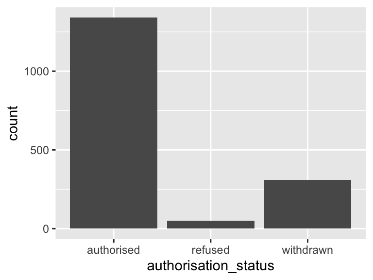

- Observed factor levels: "authorised", "refused", "withdrawn".

## generic

| Feature | Result |
| --- | --- |
| Variable type | logical |
| Number of missing obs. | 0 (0 %) |
| Number of unique values | 2 |
| Mode | “FALSE” |

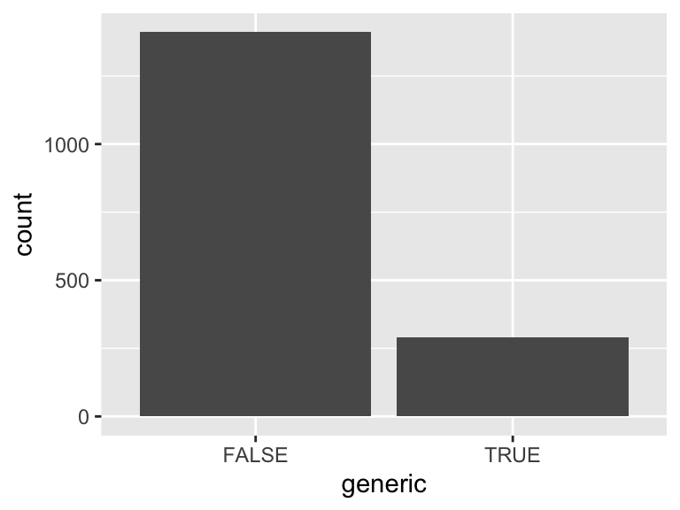

## biosimilar

| Feature | Result |
| --- | --- |
| Variable type | logical |
| Number of missing obs. | 0 (0 %) |
| Number of unique values | 2 |
| Mode | “FALSE” |

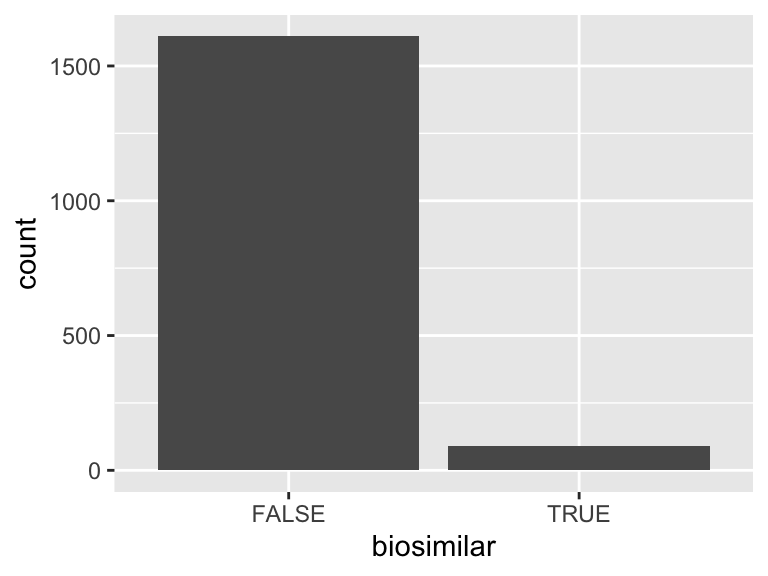

## accelerated_assessment

| Feature | Result |
| --- | --- |
| Variable type | logical |
| Number of missing obs. | 0 (0 %) |
| Number of unique values | 2 |
| Mode | “FALSE” |

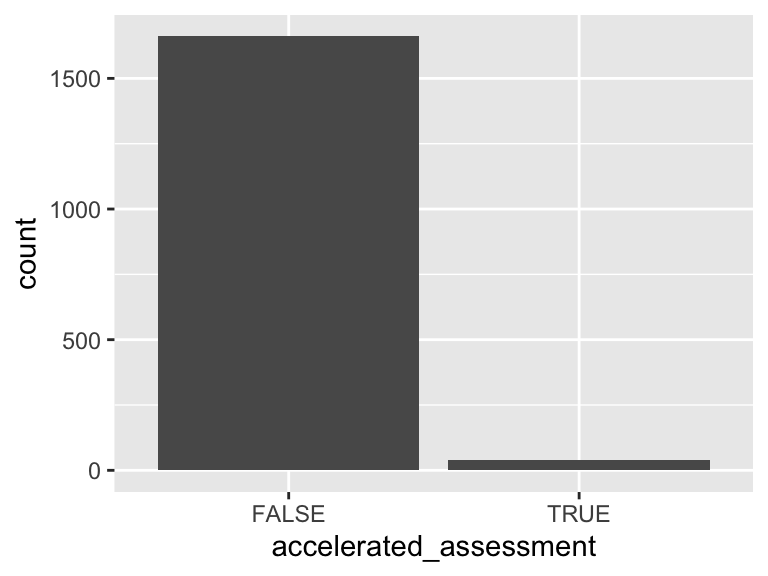

## orphan_medicine

| Feature | Result |
| --- | --- |
| Variable type | logical |
| Number of missing obs. | 0 (0 %) |
| Number of unique values | 2 |
| Mode | “FALSE” |

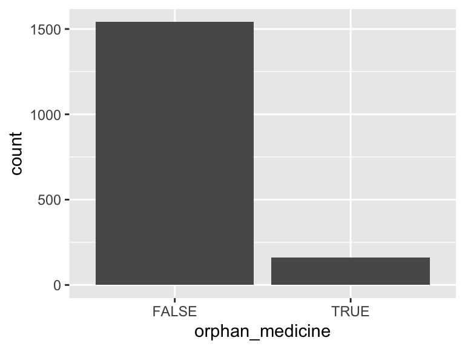

## marketing_authorisation_date

| Feature | Result |
| --- | --- |
| Variable type | Date |
| Number of missing obs. | 51 (3 %) |
| Number of unique values | 966 |
| Mode | “2021-03-26” |
| Min. and max. | 1995-10-20; 2023-02-20 |
| 1st and 3rd quartiles | 2007-09-27; 2018-05-16 |

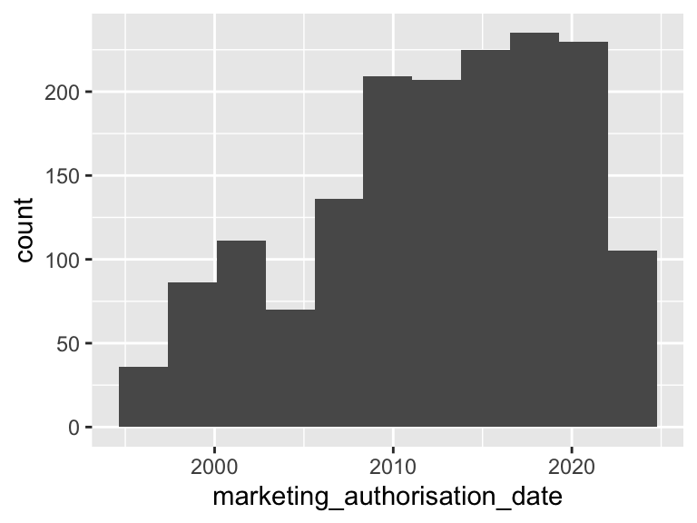

## date_of_refusal_of_marketing_authorisation

| Feature | Result |
| --- | --- |
| Variable type | Date |
| Number of missing obs. | 1630 (95.83 %) |
| Number of unique values | 63 |
| Mode | “2013-04-26” |
| Min. and max. | 2004-09-07; 2022-04-29 |
| 1st and 3rd quartiles | 2009-04-27; 2017-12-08 |

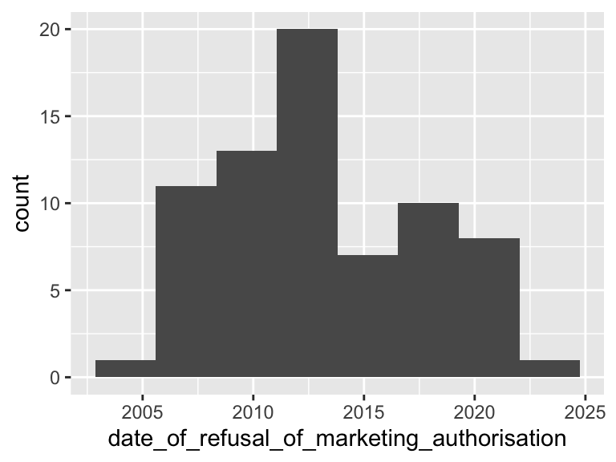

## marketing_authorisation_holder_company_name

| Feature | Result |
| --- | --- |
| Variable type | character |
| Number of missing obs. | 3 (0.18 %) |
| Number of unique values | 543 |
| Mode | “Accord Healthcare S.L.U.” |

[figure not shown]

- Observed factor levels: "“Anpharm” Przedsiębiorstwo Farmaceutyczne S.A.", "1 A Pharma GmbH", "3M Health Care Limited", "A. Menarini Industrie Farmaceutiche Riunite s.r.l.", "A.C.O.M. - Advanced Center Oncology", "AB Science", "Abbott Laboratories Ltd.", "Abbott S.r.l.", "AbbVie Deutschland GmbH Co. KG", "AbbVie Deutschland GmbH & Co. KG", "AbbVie Ltd", "Ablynx NV", "AbZ-Pharma GmbH", "Accord Healthcare S.L.U.", "Acino AG", "Acino Pharma GmbH", "Acino Pharma GmbH ", "Acorda Therapeutics Ireland Limited", "Actavis Group hf", "Actavis Group PTC ehf", "Actavis Group PTC ehf ", "Actavis Group PTC ehf ", "Actavis Group PTC ehf.", "ADC Therapeutics (NL) B.V", "Addmedica", "ADIENNE S.r.l. S.U.", "Advanced Accelerator Applications", "ADVANZ PHARMA Limited", "Advicenne S.A.", "Agios Netherlands B.V.", "Aimmune Therapeutics Ireland Limited", "Akcea Therapeutics Ireland Limited", "Akebia Europe Limited", "Albireo", "Alexion Europe SAS", "Alfasigma S.p.A.", "Alimenterics B.V.", "Allergan Pharmaceuticals International Limited", "Allergan Pharmaceuticals International Ltd", "Allos Therapeutics Ltd", "Almirall S.A", "Almirall, S.A.", "Alnylam Netherlands B.V.", "Amarin Pharmaceuticals Ireland Limited", "Amdipharm Limited", "Amersham Sorin.S.r.l.", "Amgen Europe B.V.", "Amgen Europe BV", "Amgen Technology (Ireland) UC", "Amicus Therapeutics Europe Limited", "Amivas Ireland Ltd", "Ammtek", "Amneal Pharma Europe Ltd", "Amryt AG", "Amryt Pharmaceuticals DAC", "Angelini Pharma S.p.A", "AOP Orphan Pharmaceuticals GmbH", "Apotex Europe BV", "Archie Samiel s.r.o.", "Archie Samuel s.r.o.", "Argenx", "Ascendis Pharma Endocrinology Division A/S", "Astellas Pharma Europe B.V.", "Astellas Pharma Europe BV", "Astellas Pharma GmbH", "Astra Zeneca AB", "AstraZeneca AB", "AstraZeneca AB ", "Atnahs Pharma Netherlands B.V.", "Aventis Pharma S.A.", "AVI Biopharma International Ltd", "Axunio Pharma GmbH", "Aziende Chimiche Riunite Angelini Francesco S.p.A.", "Basilea Pharmaceutica Deutschland GmbH", "Bausch + Lomb Ireland Limited", "Bausch Health Ireland Limited", "Bavarian Nordic A/S", "Baxalta Innovations GmbH", "Baxter Holding B.V.", "Bayer AG", "Bayer AG ", "Bayer Pharma AG", "Beecham Group plc", "BeiGene Ireland Ltd", "Belpharma s.a.", "bene-Arzneimittel GmbH", "Berlin-Chemie AG", "betapharm Arzneimittel GmbH", "Bial - Portela Cª, S.A.", "BIAL - Portela Ca, S.A.", "BIAL - Portela & Ca, S.A.", "Bial Portela & Companhia S.A.", "Billev Pharma Aps", "Biocodex", "Biocryst", "BioCryst Ireland Limited", "Biofrontera Bioscience GmbH", "Biogaran", "Biogen Idec Ltd", "Biogen Netherlands B.V.", "Biogen Netherlands B.V. ", "Biolitec Pharma Ltd", "BioMarin International Limited", "BioMimetic Therapeutics Ltd", "BioNTech Manufacturing GmbH", "BioPartners GmbH", "Bioprojet Pharma", "Biotest Pharma GmbH", "Biovest Europe Ltd", "Blue Earth Diagnostics Ireland Ltd", "bluebird bio (Netherlands) B.V.", "Blueprint Medicines (Netherlands) B.V.", "Boehringer Ingelheim", "Boehringer Ingelheim International GmbH", "BPL Bioproducts Laboratory GmbH", "Bracco International B.V.", "Bristol Myers Squibb Pharma EEIG", "Bristol-Myers Squibb / Pfizer EEIG", "Bristol-Myers Squibb Pharma EEIG", "Camurus AB", "Cangene Europe Limited", "Canyon Pharmaceuticals Ltd.", "Ceft Biopharma s.r.o.", "Celgene Europe BV", "Celgene Europe Ltd.", "Celltrion Healthcare Hungary Kft.", "Centocor B.V.", "Centus Biotherapeutics Europe Limited", "Chemical Works of Gedeon Richter Plc. (Gedeon Richter Plc.)", "CHEPLAPHARM Arzneimittel GmbH", "Chiesi Farmaceutici S.p.A", "Chiesi Farmaceutici S.p.A.", "Chiesi Farmaceutici SpA", "Chiron S.p.A.", "Cipla (EU) Limited", "CIS bio international", "CIS bio international ", "Clinigen Healthcare B.V.", "Clinuvel Europe Limited", "Clovis Oncology Ireland Limited", "CO.DON Gmbh", "Consilient Health Limited", "Correvio", "Corza Medical GmbH", "Covis Pharma Europe B.V.", "Crealta Pharmaceuticals Ireland Limited", "CSL Behring GmbH", "Cycle Pharmaceuticals (Europe) Ltd", "Cytonet GmbH KG", "D&A Pharma", "Daiichi Sankyo Europe GmbH", "Deciphera Pharmaceuticals (Netherlands) B.V.", "Dendreon UK Ltd", "Dipharma Arzneimittel GmbH", "Dipharma B.V.", "Diurnal Europe B.V.", "Dompé Biotec S.p.A.", "Dompe farmaceutici s.p.a.", "Dr. Falk Pharma GmbH", "Dr. Friedrich Eberth Arzneimittel GmbH", "Dr. Gerhard Mann, Chem.-Pharm. Fabrik GmbH..", "Dr. Karl Thomae GmbH", "Dynavax GmbH", "Eagle Laboratories Ltd. ", "Eckert Ziegler Radiopharma GmbH", "EigerBio Europe Limited", "Eisai GmbH", "Elan Pharma International Ltd.", "Eli Lilly Co. Ltd.", "Eli Lilly and Company (Ireland) Limited", "Eli Lilly and Company Limited", "Eli Lilly Nederland B.V.", "Eli Lilly Netherlands", "Emergent Netherlands B.V.", "Endoceutics S.A.", "ERA Consulting GmbH", "Estetra SPRL", "Esteve Pharmaceuticals GmbH", "Esteve Pharmaceuticals, S.A.", "Eurocept International B. V.", "Eurocept International BV", "EuroGenerics Holdings B.V.", "EUSA Pharma (Netherlands) BV", "Evans Vaccines Ltd.", "Evolus Pharma B.V.", "Ferrer Internacional S.A.", "Ferring Pharmaceuticals A/S", "FGK Representative Service GmbH", "Fresenius Kabi Deutschland GmbH", "Galderma International", "Galpharm Healthcare Ltd.", "GE Healthcare AS", "GE Healthcare AS ", "GE Healthcare B.V.", "Gedeon Richter", "Gedeon Richter Ltd ", "Gedeon Richter Plc.", "Gen.Orph", "Gennisium Pharma", "Genta Development Ltd. c/o Ross Craig", "Gentium S.r.l.", "Genzyme Europe B.V.", "Genzyme Europe BV", "Gilead Sciences International Limited", "Gilead Sciences International Ltd", "Gilead Sciences International Ltd ", "Gilead Sciences Ireland UC", "Gilead Sciences Ireland UC, Galapagos NV", "Gilead Sciences Ireland Unlimited Company", "Glaxo Group Limited ", "Glaxo Group Ltd", "Glaxo Group Ltd.", "GlaxoSmithKline (Ireland) Limited", "GlaxoSmithKline Biologicals S.A.", "GlaxoSmithKline Biologicals S.A. ", "GlaxoSmithkline Biologicals SA", "GlaxoSmithKline Dungarvan Limited", "GlaxoSmithKline Trading Services", "GlaxoSmithKline Trading Services Limited", "Glenmark Arzneimittel GmbH", "Glenmark Pharmaceuticals s.r.o. ", "Global Blood Therapeutics Netherlands B. V.", "GMP-Orphan SA", "Grunenthal GmbH", "Grünenthal GmbH", "GSK Vaccines S.r.l.", "Guidehouse Germany GmbH", "GW Pharma (International) B.V.", "H. Lundbeck A/S", "Hansa Biopharma AB", "HCS bvba ", "Helsinn Birex Pharmaceuticals Ltd", "Helsinn Birex Pharmaceuticals Ltd.", "Heron Therapeutics, B.V.", "Hexal AG", "Hexal AG ", "Hikma Farmaceutica (Portugal) S.A.", "Holostem Terapie Avanzate s.r.l.", "Horizon Therapeutics Ireland DAC", "Hospira UK Limited", "HRA Pharma Rare Diseases", "I.D.B. Radiopharmacy B.V.", "Idorsia Pharmaceuticals Deutschland GmbH", "Immedica Pharma AB", "Immunocore Ireland Limited", "Immunomedics GmbH", "Inceptua AB", "Incline Therapeutics Europe Ltd", "Incyte Biosciences Distribution B.V.", "Indivior Europe Limited", "INFAI, Institut für biomedizinische Analytik NMR-Imaging GmbH", "Insmed Netherlands B.V.", "Instituto Grifols S.A.", "Instituto Grifols, S.A.", "Ipsen Pharma", "ITM Medical Isotopes GmbH", "Janssen Biologics B.V.", "Janssen Biologics B.V. ", "Janssen Cilag International NV", "Janssen-Cilag International N.V.", "Janssen-Cilag International N.V. ", "Janssen-Cilag International N.V. ", "Janssen-Cilag International NV", "Jazz Pharmaceuticals Ireland Limited", "Jenson Pharmaceutical Services Limited", "JensonR+ Limited", "Juta Pharma GmbH", "Kite Pharma EU B.V.", "Koanaa Healthcare GmbH", "Krka", "KRKA d.d.", "KRKA, d.d.", "Krka, d.d., Novo mesto", "KRKA, d.d., Novo mesto", "Krka, d.d., Novo mesto ", "KS Biomedix Limited", "Kyowa Kirin Holdings B.V.", "L. Molteni & C. dei Fratelli Alitti Società di Esercizio S.p.A.", "Laboratoire Aguettant", "Laboratoire Francais du Fractionnement et des Biotechnologies", "Laboratoire HRA Pharma", "Laboratoires 3M Santé", "Laboratoires CTRS", "Laboratoires CTRS ", "Laboratoires Delbert", "Laboratoires SMB S.A.", "Laboratoires SMB S.A. ", "Laboratorios Farmacéuticos Rovi, S.A.", "Laboratorios Lesvi S.L.", "Lantheus EU Limited", "Leadiant GmbH", "LEO Laboratories Ltd.", "LEO Pharma A/S", "Les Laboratoires Servier", "Life Radiopharma Berlin GmbH", "Linde Healthcare AB", "Lipomed GmbH", "Lucane Pharma", "Lupin Europe GmbH", "Mabxience Research SL", "Mallinckrodt Deutschland GmbH", "Mallinckrodt Pharmaceuticals Ireland Limited", "Marvel Lifesciences Ltd", "MCM Vaccine B.V.", "MDS Nordion S.A.", "Meda AB", "Medac", "Medac Gesellschaft fuer klinische Spezialpraeparate mbH", "medac Gesellschaft für klinische Spezialpräparate mbH", "Medice Arzneimittel Pütter GmbH Co. KG", "MedImmune LLC", "MediWound Germany GmbH", "Medtronic BioPharma B.V.", "Menarini International Operations Luxembourg S.A.", "Menarini International Operations Luxembourg S.A. (MIOL)", "MendeliKABS Europe Ltd", "Merck Europe B.V.", "Merck Europe B.V. ", "Merck Sharp Dohme Limited", "Merck Sharp Dohme Ltd", "Merck Sharp Dohme Ltd ", "Merck Sharp Dohme Ltd.", "Merck Sharp & Dohme B.V.", "Merck Sharp & Dohme B.V. ", "Merck Sharp and Dohme B.V", "Merz Pharmaceuticals GmbH", "Merz Pharmaceuticals GmbH ", "Midas Pharma GmbH", "Mirum Pharmaceuticals International B.V.", "Mitsubishi Pharma Europe Ltd", "Moderna Biotech Spain, S.L.", "MolMed SpA", "Mundipharma Corporation (Ireland) Limited", "Mylan dura GmbH", "Mylan IRE Healthcare Limited", "Mylan IRE Healthcare Ltd", "Mylan Ireland Limited", "Mylan Pharmaceuticals Limited", "Mylan S.A.S", "Mylan S.A.S.", "N.V. Organon", "Nabriva Therapeutics Ireland DAC", "Nanotherapeutics Bohumil, s.r.o.", "Navidea Biopharmaceuticals Europe Ltd.", "Nektar Therapeutics UK Limited", "Neovii Biotech GmbH", "NeuTec Pharma plc", "Noden Pharma DAC", "Nordic Group B.V.", "Norgine B.V.", "Norton Healthcare Ltd.", "Nova Laboratories Ireland Limited", "Novartis Europharm Limited", "Novartis Europharm Limited ", "Novartis Europharm Ltd", "Novartis Europharm Ltd.", "Novartis Ireland Ltd", "Novartis Ophthalmics Europe Ltd.", "Novartis Vaccines and Diagnostics S.r.l.", "Novavax CZ, a.s.", "Novo Nordisk A/S", "NPS Pharma Holdings Limited", "Obvius Investment B.V.", "Octapharma AB", "Ology Bioservices Ireland LTD", "Olympus Biotech International Limited", "Omrix Biopharmaceuticals N. V.", "Oncopeptides AB", "Orchard Therapeutics (Netherlands) BV", "Orexigen Therapeutics Ireland Limited", "Orion Corporation", "ORPHELIA Pharma SAS", "Otsuka Novel Products GmbH", "Otsuka Pharmaceutical Netherlands B.V.", "Pacira Ireland Limited", "Pacira Limited", "PAION Deutschland GmbH", "Pari Pharma GmbH", "Passauer Pharma GmbH", "Pasteur Mà¨rieux MSD", "Pfizer Europe MA EEIG", "Pfizer Europe MA EEIG ", "Pfizer Ireland Pharmaceuticals", "Pfizer Limited", "Pfizer Ltd.", "Pfizer Ltd. ", "Pharma Mar S.A.", "Pharmacia - Pfizer EEIG", "Pharmacia Europe EEIG", "PharmaSwiss Ceska Republika s.r.o", "Pharmathen S.A.", "Pharmaxis Europe Limited", "Pharming Group N.V.", "Phoenix Labs Unlimited Company", "Photonamic GmbH & Co. KG", "Pierre Fabre Medicament", "Pinax Pharma GmbH", "Pinnacle Biologics B.V. ", "Piramal Critical Care B.V.", "Plethora Pharma Solutions Limited", "Portola Pharma UK Limited", "Proveca Pharma Limited", "Provepharm SAS", "PTC Therapeutics International Limited", "Qualimed", "RAD Neurim Pharmaceuticals EEC SARL", "Radius Health Ireland Ltd", "ratiopharm GmbH", "Ratiopharm GmbH", "Rayner Surgical (Ireland) Limited", "Recordati Ireland Ltd", "Recordati Ireland Ltd.", "Recordati Rare Diseases", "Regeneron Ireland Designated Activity Company (DAC)", "Regeneron UK Limited", "Renable Pharma Limited", "Resilience Biomanufacturing Ireland Limited", "Retrophin Europe Ltd", "Rhythm Pharmaceuticals Netherlands B.V.", "Roche Registration GmbH", "Roche Registration GmbH ", "Roche Registration Limited", "Roche Registration Ltd.", "Rotterdam Biologics B.V.", "Samsung Bioepis NL B.V.", "Sandoz GmbH", "Sandoz Pharmaceuticals d.d.", "Sanofi Belgium", "Sanofi Mature IP", "Sanofi Pasteur", "Sanofi Pasteur Europe", "Sanofi Pasteur MSD, SNC", "Sanofi Pasteur S.A.", "Sanofi Winthrop Industrie", "sanofi-aventis", "sanofi-aventis Deutschland GmbH", "Sanofi-aventis Deutschland GmbH", "Sanofi-Aventis Groupe", "sanofi-aventis groupe ", "Sanquin Plasma Products B.V.", "Santen Oy", "Santhera Pharmaceuticals (Deutschland) GmbH", "Schering-Plough Europe", "SciPharm Sàrl", "Seagen B.V.", "Secura Bio Limited", "Seqirus GmbH", "Seqirus Netherlands B.V.", "Seqirus S.r.l. ", "SERB SA", "SERB SAS", "Serono Europe Limited", "Servier (Ireland) Industries Ltd", "SFL Pharmaceuticals Deutschland GmbH", "Shionogi B.V.", "Shire Pharmaceutical Contracts Limited", "SIGA Technologies Netherlands B.V.", "Sipaco Internacional Lda.", "Sloan Pharma S.a.r.l", "SmithKline Beecham Ltd", "SmithKline Beecham Plc", "Sonus Pharmaceuticals Ltd.", "Stada Arzneimittel AG", "STADA Arzneimittel AG", "STEBA Biotech S.A", "Stemline Therapeutics B.V.", "Strides Pharma (Cyprus) Limited", "Substipharm", "SUN Pharmaceutical Industries (Europe) B.V.", "Sun Pharmaceutical Industries Europe B.V.", "Swedish Orphan Biovitrum AB", "Swedish Orphan Biovitrum AB (publ)", "Swedish Orphan Biovitrum International AB", "Tad Pharma GmbH", "Takeda Europe R Centre Ltd.", "Takeda France SAS", "Takeda GmbH", "Takeda Manufacturing Austria AG", "Takeda Pharma A/S", "Takeda Pharmaceuticals International AG", "Takeda Pharmaceuticals International AG Ireland", "Takeda Pharmaceuticals International AG Ireland Branch", "Taw Pharma (Ireland) Limited", "Techdow Pharma Netherlands B.V. ", "TESARO Bio Netherlands B.V.", "Tetris Pharma B.V", "Teva B.V", "Teva B.V.", "Teva B.V. ", "Teva Generics B.V", "Teva GmbH", "Teva Pharma B.V.", "Teva Pharma B.V. ", "Teva Pharma GmbH", "The Medicines Company UK Ltd", "Therakind (Europe) Limited", "Theramex Ireland Limited", "Theratechnologies Europe Limited", "Theravance Biopharma Ireland Umited", "TiGenix N.V.", "Tillotts Pharma GmbH", "TLC Biopharmaceuticals B.V.", "TMC Pharma (EU) Limited", "TMC Pharma Services Ltd.", "Torbet Laboratories Ireland Limited", "UCB Pharma Ltd", "UCB Pharma S.A.", "UCB Pharma S.A. ", "UCB Pharma SA", "UCB Pharma SA ", "Ultragenyx Germany GmbH", "Unigene UK Ltd.", "uniQure biopharma B.V. ", "United Therapeutics Europe Ltd", "Univar Solutions BV", "Upjohn EESV", "Vaia S.A.", "Valneva Austria GmbH", "Valneva Sweden AB", "Vanda Pharmaceuticals Ltd", "Vanda Pharmaceuticals Netherlands B.V.", "VBI Vaccines B.V.", "Vericel Denmark ApS", "Vertex Pharmaceuticals (Ireland) Limited", "Viatris Healthcare Limited", "Viatris Limited", "Vifor Fresenius Medical Care Renal Pharma France", "ViiV Healthcare B.V.", "ViiV Healthcare BV", "Vivus BV", "Warner Chilcott Deutschland GmbH", "Warner Chilcott UK Ltd.", "Wyeth Europa Ltd", "Wyeth Lederle Vaccines S.A.", "XBiotech Germany GmbH", "YES Pharmaceutical Development Services GmbH", "Zaklady FarmaFarmaceutyczne Polpharma S.Aceutyczne Polpharma S.A.", "Zambon SpA", "Zentiva k.s.", "Zentiva, k.s.", "Zogenix ROI Limited", "zr pharma& GmbH", "Zydus France S.A.S.".

## holder_name

| Feature | Result |
| --- | --- |
| Variable type | character |
| Number of missing obs. | 3 (0.18 %) |
| Number of unique values | 378 |
| Mode | “Novartis” |

[figure not shown]

- Observed factor levels: "1", "3M", "A", "AB", "Abbott", "AbbVie", "Ablynx", "AbZ", "Accord", "Acino", "Acorda", "Actavis", "ADC", "Addmedica", "ADIENNE", "Advanced", "ADVANZ", "Advicenne", "Agios", "Aimmune", "Akcea", "Akebia", "Albireo", "Alexion", "Alfasigma", "Alimenterics", "Allergan", "Allos", "Almirall", "Alnylam", "Amarin", "Amdipharm", "Amersham", "Amgen", "Amicus", "Amivas", "Ammtek", "Amneal", "Amryt", "Angelini", "Anpharm", "AOP", "Apotex", "Archie", "Argenx", "Ascendis", "Astellas", "Astra", "AstraZeneca", "Atnahs", "Aventis", "AVI", "Axunio", "Aziende", "Basilea", "Bausch", "Bavarian", "Baxalta", "Baxter", "Bayer", "Beecham", "BeiGene", "Belpharma", "bene", "Berlin", "betapharm", "Bial", "BIAL", "Billev", "Biocodex", "Biocryst", "BioCryst", "Biofrontera", "Biogaran", "Biogen", "Biolitec", "BioMarin", "BioMimetic", "BioNTech", "BioPartners", "Bioprojet", "Biotest", "Biovest", "Blue", "bluebird", "Blueprint", "Boehringer", "BPL", "Bracco", "BristolMyersSquibb", "Camurus", "Cangene", "Canyon", "Ceft", "Celgene", "Celltrion", "Centocor", "Centus", "Chemical", "CHEPLAPHARM", "Chiesi", "Chiron", "Cipla", "CIS", "Clinigen", "Clinuvel", "Clovis", "CO", "Consilient", "Correvio", "Corza", "Covis", "Crealta", "CSL", "Cycle", "Cytonet", "D", "Daiichi", "Deciphera", "Dendreon", "Dipharma", "Diurnal", "Dompe", "Dompé", "Dr", "Dynavax", "Eagle", "Eckert", "EigerBio", "Eisai", "Elan", "Eli Lilly", "Emergent", "Endoceutics", "ERA", "Estetra", "Esteve", "Eurocept", "EuroGenerics", "EUSA", "Evans", "Evolus", "Ferrer", "Ferring", "FGK", "Fresenius", "Galderma", "Galpharm", "GE", "Gedeon", "Gen", "Gennisium", "Genta", "Gentium", "Genzyme", "Gilead", "Glaxo", "GlaxoSmithkline", "GlaxoSmithKline", "Glenmark", "Global", "GMP", "Grunenthal", "Grünenthal", "GSK", "Guidehouse", "GW", "H", "Hansa", "HCS", "Helsinn", "Heron", "Hexal", "Hikma", "Holostem", "Horizon", "Hospira", "HRA", "I", "Idorsia", "Immedica", "Immunocore", "Immunomedics", "Inceptua", "Incline", "Incyte", "Indivior", "INFAI", "Insmed", "Instituto", "Ipsen", "ITM", "J&J", "Jazz", "Jenson", "JensonR", "Juta", "Kite", "Koanaa", "Krka", "KRKA", "KS", "Kyowa", "L", "Laboratoire", "Laboratoires", "Laboratorios", "Lantheus", "Leadiant", "LEO", "Life", "Linde", "Lipomed", "Lucane", "Lupin", "Mabxience", "Mallinckrodt", "Marvel", "MCM", "MDS", "Meda", "medac", "Medac", "Medice", "MedImmune", "MediWound", "Medtronic", "Menarini", "MendeliKABS", "Merck", "Merz", "Midas", "Mirum", "Mitsubishi", "Moderna", "MolMed", "Mundipharma", "Mylan", "Nabriva", "Nanotherapeutics", "Navidea", "Nektar", "Neovii", "NeuTec", "Noden", "Nordic", "Norgine", "Norton", "Nova", "Novartis", "Novavax", "Novo", "NPS", "Obvius", "Octapharma", "Ology", "Olympus", "Omrix", "Oncopeptides", "Orchard", "Orexigen", "Organon", "Orion", "ORPHELIA", "Otsuka", "Pacira", "PAION", "Pari", "Passauer", "Pasteur", "Pfizer", "Pharma", "Pharmacia", "PharmaSwiss", "Pharmathen", "Pharmaxis", "Pharming", "Phoenix", "Photonamic", "Pierre", "Pinax", "Pinnacle", "Piramal", "Plethora", "Portola", "Proveca", "Provepharm", "PTC", "Qualimed", "RAD", "Radius", "ratiopharm", "Ratiopharm", "Rayner", "Recordati", "Regeneron", "Renable", "Resilience", "Retrophin", "Rhythm", "Roche", "Rotterdam", "Samsung", "Sandoz", "sanofi", "Sanofi", "Sanquin", "Santen", "Santhera", "Schering", "SciPharm", "Seagen", "Secura", "Seqirus", "SERB", "Serono", "Servier", "SFL", "Shionogi", "Shire", "SIGA", "Sipaco", "Sloan", "SmithKline", "Sonus", "Stada", "STADA", "STEBA", "Stemline", "Strides", "Substipharm", "Sun", "SUN", "Swedish", "Tad", "Takeda", "Taw", "Techdow", "TESARO", "Tetris", "Teva", "The", "Therakind", "Theramex", "Theratechnologies", "Theravance", "TiGenix", "Tillotts", "TLC", "TMC", "Torbet", "UCB", "Ultragenyx", "Unigene", "uniQure", "United", "Univar", "Upjohn", "Vaia", "Valneva", "Vanda", "VBI", "Vericel", "Vertex", "Viatris", "Vifor", "ViiV", "Vivus", "Warner", "Wyeth", "XBiotech", "YES", "Zaklady", "Zambon", "Zentiva", "Zogenix", "zr", "Zydus".

## brandname

| Feature | Result |
| --- | --- |
| Variable type | logical |
| Number of missing obs. | 0 (0 %) |
| Number of unique values | 2 |
| Mode | “TRUE” |

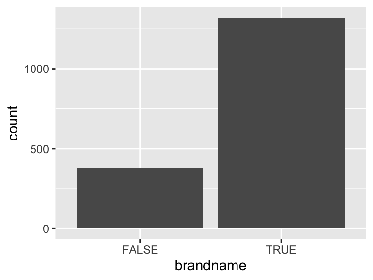

## year

| Feature | Result |
| --- | --- |
| Variable type | numeric |
| Number of missing obs. | 0 (0 %) |
| Number of unique values | 29 |
| Median | 2013 |
| 1st and 3rd quartiles | 2007; 2018 |
| Min. and max. | 1995; 2023 |

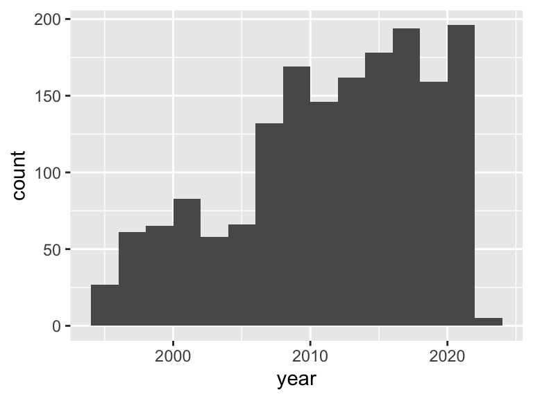

Report generation information:

- Created by: zhangdoan (username: `zhangdoan`).
- Report creation time: Mon Apr 17 2023 00:58:35
- Report was run from directory: `/Users/zhangdoan/Desktop/data`
- dataReporter v1.0.2 [Pkg: 2021-11-11 from CRAN (R 4.1.0)]
- R version 4.1.1 (2021-08-10).
- Platform: x86_64-apple-darwin17.0 (64-bit)(macOS Big Sur 10.16).
- Function call: `dataReporter::makeDataReport(data = drugs, mode = c("summarize", "visualize", "check"), smartNum = FALSE, file = "codebook_drugs.Rmd", replace = TRUE, checks = list(character = "showAllFactorLevels", factor = "showAllFactorLevels", labelled = "showAllFactorLevels", haven_labelled = "showAllFactorLevels", numeric = NULL, integer = NULL, logical = NULL, Date = NULL), listChecks = FALSE, maxProbVals = Inf, codebook = TRUE, reportTitle = "Codebook for drugs")`